# **Project 1: An Analysis of Montgomery County, Maryland Crash Data**

**Antonio Vega, Samuel Westigard**

The following report uses crash data collected by the Automated Crash Reporting System (ACRS) of the Maryland State Police  
The data contains approximately 87,000 entries with attributes such as Collision Type, Crash Date/Time and Weather. A full list of attributes is provided below.

There are two main focuses for the exploration of the data:

1. The relationship between Time of Day, Collision Type, and Injury Severity
2. The relationship between Weather and Number of Accidents and Drug Use

## **Initial Exploration**

To begin with we want a better idea about the state of the information collected in the crash data.

```r
dat = read.csv("C:\\Users\\Sam\\Desktop\\CST 383\\Project1\\Crash_Reporting_-_Drivers_Data.csv")
names(dat)
```

```
##  [1] "Report.Number"                "Local.Case.Number"
##  [3] "Agency.Name"                  "ACRS.Report.Type"
##  [5] "Crash.Date.Time"              "Route.Type"
##  [7] "Road.Name"                    "Cross.Street.Type"
##  [9] "Cross.Street.Name"            "Off.Road.Description"
## [11] "Municipality"                 "Related.Non.Motorist"
## [13] "Collision.Type"               "Weather"
## [15] "Surface.Condition"            "Light"
## [17] "Traffic.Control"              "Driver.Substance.Abuse"
## [19] "Non.Motorist.Substance.Abuse" "Person.ID"
## [21] "Driver.At.Fault"              "Injury.Severity"
## [23] "Circumstance"                 "Driver.Distracted.By"
## [25] "Drivers.License.State"        "Vehicle.ID"
## [27] "Vehicle.Damage.Extent"        "Vehicle.Body.Type"
## [29] "Vehicle.Movement"             "Latitude"
## [31] "Longitude"                    "Location"
```

```r
length(names(dat))
```

```
## [1] 32
```

```r
nrow(dat)
```

```
## [1] 86046
```

There are 32 different columns in data with 86046 rows.

```r
sum(is.na(dat))
```

```
## [1] 1
```

We see there are almost no NA in the data. This seems good but next we will look at the contents of a couple of the columns to determine if there are any strange values that may mess with our results.

```r
table(dat$Injury.Severity)
```

```
##
##             FATAL INJURY       NO APPARENT INJURY          POSSIBLE INJURY
##                       59                    69769                     8798
##   SUSPECTED MINOR INJURY SUSPECTED SERIOUS INJURY
##                     6677                      743
```

```r
table(dat$Collision.Type)
```

```
##
##     ANGLE MEETS LEFT HEAD ON        ANGLE MEETS LEFT TURN
##                          344                          989
##       ANGLE MEETS RIGHT TURN                      HEAD ON
##                          580                         1799
##            HEAD ON LEFT TURN                          N/A
##                         6713                          277
##  OPPOSITE DIR BOTH LEFT TURN OPPOSITE DIRECTION SIDESWIPE
##                          168                         1361
##                        OTHER      SAME DIR BOTH LEFT TURN
##                         8988                          350
##            SAME DIR REAR END      SAME DIR REND LEFT TURN
##                        30066                          457
##     SAME DIR REND RIGHT TURN     SAME DIRECTION LEFT TURN
##                          462                         1809
##    SAME DIRECTION RIGHT TURN     SAME DIRECTION SIDESWIPE
##                         1909                         7514
##               SINGLE VEHICLE      STRAIGHT MOVEMENT ANGLE
##                         7803                        14097
##                      UNKNOWN
##                          360
```

The values “N/A”, “OTHER”, “UNKOWN” from the Collision Type column do not represent significant results so when we are plotting the date we make the decision to exclude rows with those values.

## **Accidents by Time of Day**

First we want to explore if there is a relationship between time and number of crashes.

Time in the data set is given as a date time object, so it will first be converted to a format where it will be easier to extract the hours.

```r
date_time = dat$Crash.Date.Time
dat$dtime = strptime(as.character(date_time),
                 "%m/%d/%Y %I:%M:%S %p",
                 tz="America/New_York")
```

Here is a comparison of the old Date/Time objects with the new formatted ones

```r
head(dat$Crash.Date.Time)
```

```
## [1] 12/11/2015 07:39:00 AM 05/31/2016 11:03:00 AM 06/27/2016 12:28:00 PM
## [4] 06/29/2016 12:48:00 PM 06/25/2016 08:40:00 PM 01/15/2017 01:10:00 AM
## 46790 Levels: 01/01/2015 01:10:00 AM ... 12/31/2018 12:58:00 PM
```

```r
head(dat$dtime)
```

```
## [1] "2015-12-11 07:39:00 EST" "2016-05-31 11:03:00 EDT"
## [3] "2016-06-27 12:28:00 EDT" "2016-06-29 12:48:00 EDT"
## [5] "2016-06-25 20:40:00 EDT" "2017-01-15 01:10:00 EST"
```

Finally, the extracted hours from the rows can be plotted

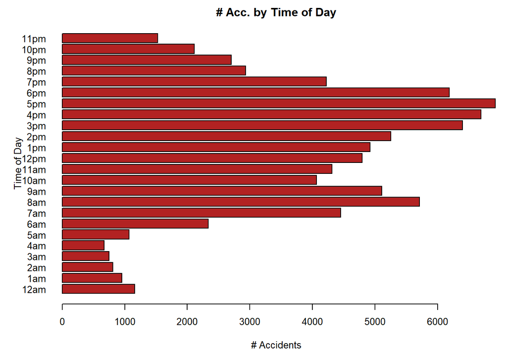

```r
par(mar=c(5,5,2,1), mfrow=c(1,1), cex=.8)
barplot(table(dat$dtime$hour),ylab="Time of Day",xlab="# Accidents", horiz=T, las =1, main="# Acc. by Time of Day", col="firebrick",
        names.arg=c("12am", "1am", "2am", "3am", "4am", "5am" ,
                                      "6am", "7am", "8am", "9am", "10am",
                                      "11am", "12pm", "1pm", "2pm", "3pm",
                                      "4pm", "5pm", "6pm", "7pm", "8pm", "9pm", "10pm",
                                      "11pm"
                                      )
        )
```

It appears that there are two spikes of accidents around 8am and 5pm. This makes sense because more cars will be on the road at that time because of rush hour.

### **Accidents by Collision Type**

### **Accidents by Collision Type and Time of Day**

Next, building on the same graph, we want to see if the proportion of type of collisions changed depending on the time of day. Before doing so we first will look at Collision Types as a single variable

Before plotting, we will look at the different values for Collision Type

```r
table(dat$Collision.Type)
```

```
##
##     ANGLE MEETS LEFT HEAD ON        ANGLE MEETS LEFT TURN
##                          344                          989
##       ANGLE MEETS RIGHT TURN                      HEAD ON
##                          580                         1799
##            HEAD ON LEFT TURN                          N/A
##                         6713                          277
##  OPPOSITE DIR BOTH LEFT TURN OPPOSITE DIRECTION SIDESWIPE
##                          168                         1361
##                        OTHER      SAME DIR BOTH LEFT TURN
##                         8988                          350
##            SAME DIR REAR END      SAME DIR REND LEFT TURN
##                        30066                          457
##     SAME DIR REND RIGHT TURN     SAME DIRECTION LEFT TURN
##                          462                         1809
##    SAME DIRECTION RIGHT TURN     SAME DIRECTION SIDESWIPE
##                         1909                         7514
##               SINGLE VEHICLE      STRAIGHT MOVEMENT ANGLE
##                         7803                        14097
##                      UNKNOWN
##                          360
```

The three values “UNKNOWN”, “N/A”, “OTHER” are not significant so we will remove them from our plotting

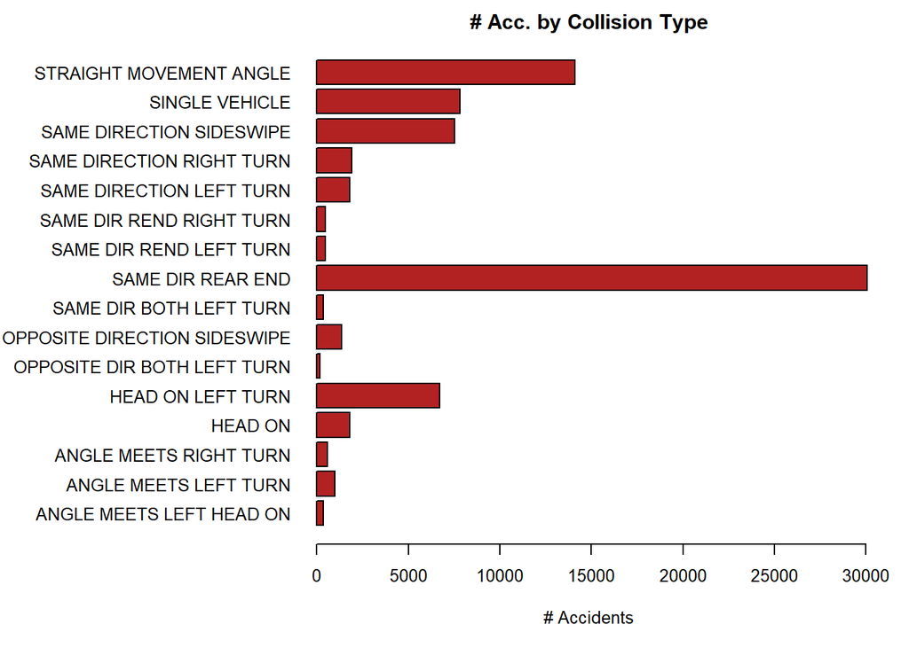

```r
par(mar=c(5,15,2,2), cex=.8)
tbl = table(dat$Collision.Type, exclude=c("OTHER", "UNKNOWN", "N/A"))
barplot(tbl, horiz=T, las=1, col="firebrick", main="# Acc. by Collision Type", xlab="# Accidents")
```

From the graph we can see that Same Direction Rear Ends are the main collision types, with Straight Movement Angle, Single Vehicle and Same Direction Sideswipe being the other common ones.

Now the two previous graphs will be combined to see if collision types are more common at different times of the day.

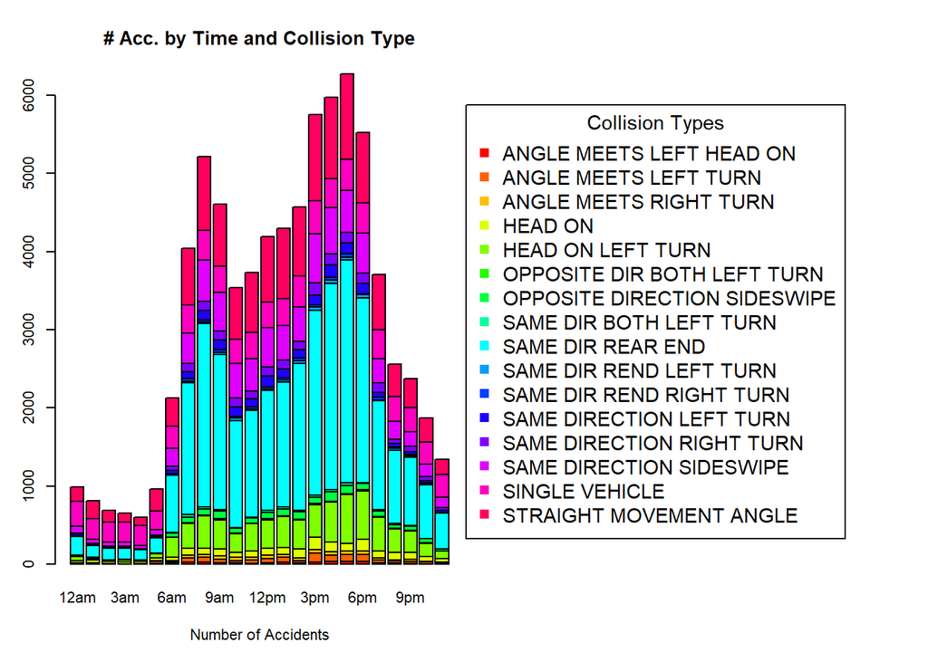

```r
par(mar=c(5,3,4,0), xpd=T, mfrow=c(1,2), cex=.7)
tbl1 = table(dat$Collision.Type, dat$dtime$hour, exclude=c("OTHER", "UNKNOWN", "N/A"))
num_colors = 16

barplot(tbl1, col=rainbow(num_colors), xlab="Number of Accidents", main="# Acc. by Time and Collision Type"
        , names.arg=c("12am", "1am", "2am", "3am", "4am", "5am" ,
                      "6am", "7am", "8am", "9am", "10am",
                      "11am", "12pm", "1pm", "2pm", "3pm","4pm",
                      "5pm", "6pm", "7pm", "8pm", "9pm", "10pm", "11pm")
)

plot.new()
legend("left", rownames(tbl1),cex=1.3, inset=c(-.13,0), pch=15,
      col=rainbow(num_colors), title="Collision Types")
```

One interesting difference we can see is that in the early morning, Same Direction Sideswipes become much more common. This might be because of poor lighting and tired drivers not paying attention.

### **Accidents by Light and Collision Type**

To learn more about whether poor lighting is a factor in the incidence of Same Direction Sideswipes we will now plot Collision Type with Light

Like before, our first step is to exclude all “OTHER”, “UNKNOWN” or “N/A” values

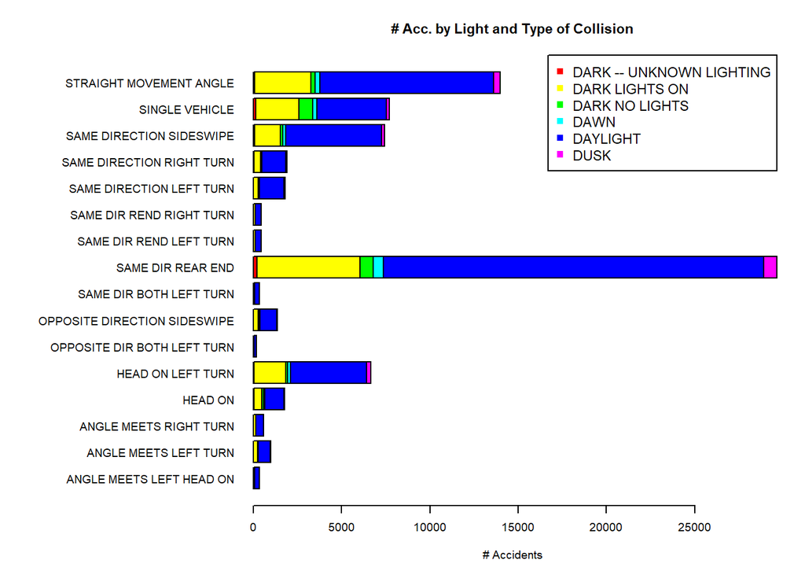

```r
par(mar=c(5,18,4,2), xpd=T, mfrow=c(1,1), cex=.6)
tbl = table(dat$Light, dat$Collision.Type, exclude=c("OTHER", "UNKNOWN", "N/A"))
num_colors = 6
barplot(tbl, horiz=T, las=1, col=rainbow(num_colors), main="# Acc. by Light and Type of Collision", xlab="# Accidents")
legend("topright", rownames(tbl), cex=1.2, pch=15, col=rainbow(num_colors))
```

Interestingly, from this perspective it appears that the only Collision Types that often occur at night are Straight Movement Angle, Single Vehicle, Same Direction Sideswipe, Same Direction Rear End, and Head On Left Turn. It appears these types of collisions are most susceptible to light.

### **Accidents by Injury Severity and Collision Type**

Another interesting association to explore is the relationship between Injury Severity and Type of Collision, so now we will plot that

As with our other plots we first exclude “OTHER”, “UNKNOWN”, and “N/A” from our results

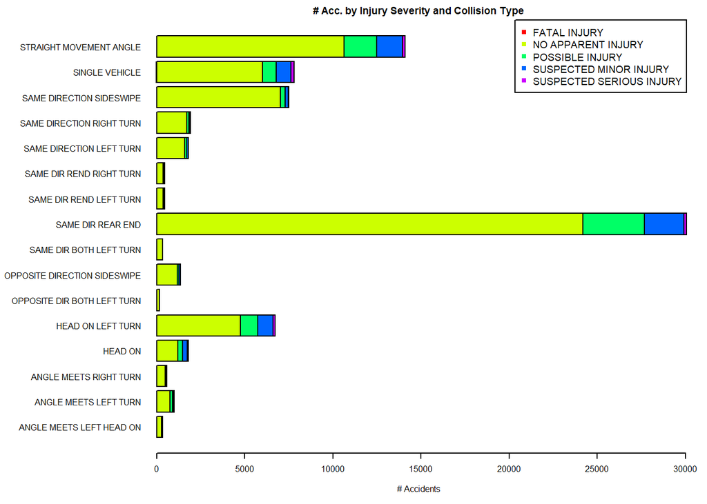

```r
par(mar=c(5,15,2,2), xpd=T, cex=.5)
tbl = table(dat$Injury.Severity, dat$Collision.Type, exclude=c("OTHER", "UNKNOWN", "N/A"))
num_colors = 5
barplot(tbl, horiz=T, las=1, col=rainbow(num_colors), main="# Acc. by Injury Severity and Collision Type", xlab="# Accidents")
legend("topright", rownames(tbl), cex=1.2, pch=15, col=rainbow(num_colors))
```

### **Accidents By Month**

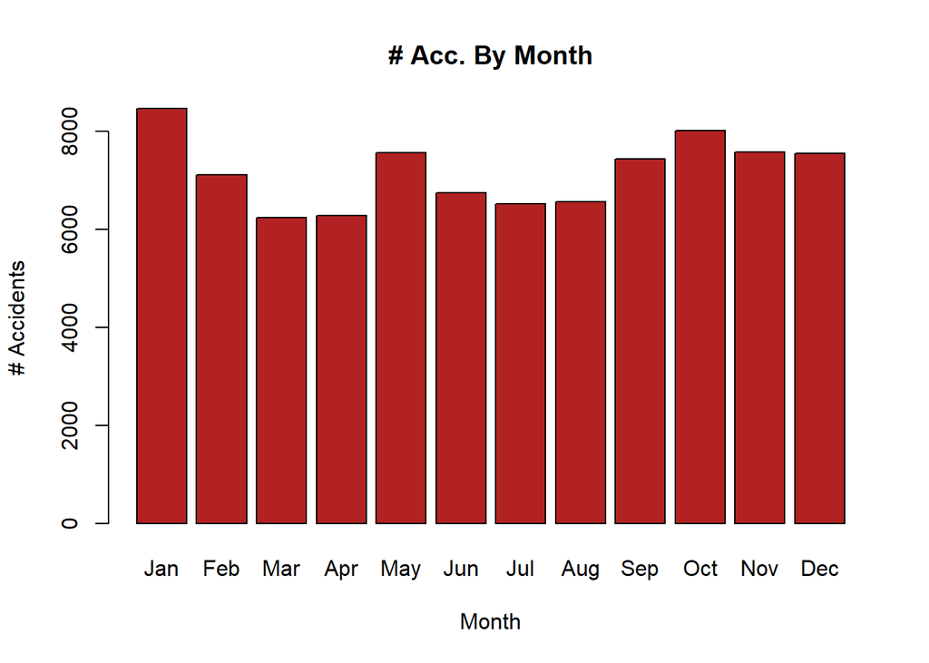

```r
dat$dtime = strptime(as.character(dat$Crash.Date.Time),
                     "%m/%d/%Y %I:%M:%S %p",
                     tz="America/New_York")
months = dat$dtime$mon
mnames=c("Jan","Feb","Mar","Apr","May","Jun","Jul","Aug","Sep","Oct","Nov","Dec")
barplot(table(months),main="# Acc. By Month",ylab="# Accidents",xlab="Month", horiz=FALSE, names.arg=mnames, col="firebrick")
```

After analyzing the data above, we wanted to see why certain months had more crashes. We thought weather may be a factor.

### **Number of Accidents by Month and Weather**

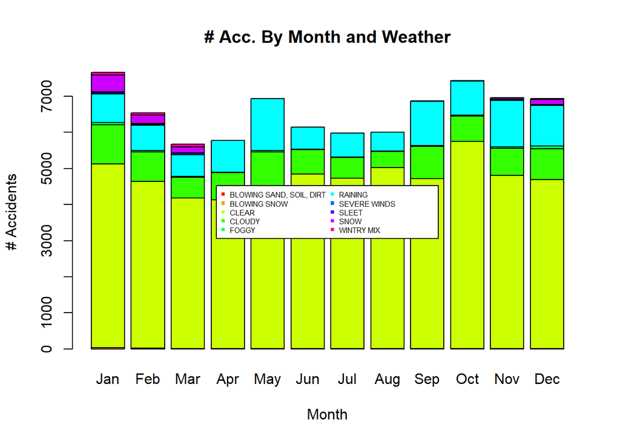

```r
num_colors = 10
dat$dtime = strptime(as.character(dat$Crash.Date.Time),
                     "%m/%d/%Y %I:%M:%S %p",
                     tz="America/New_York")
tbl1 = table(dat$Weather,dat$dtime$mon, exclude=c("OTHER","UNKNOWN","N/A"))
  barplot(tbl1,names.arg=mnames,main="# Acc. By Month and Weather",ylab="# Accidents",xlab="Month",
  col=rainbow(num_colors))
legend("center",
       rownames(tbl1),
       col=rainbow(num_colors),
       ncol = 2,
       cex = 0.5, inset = c(-1,-.2), pch=15)
```

### **Accidents in Rain by Month**

Although most crashes happened during clear weather (green), it seems that the month May had more rain. We graphed the crashes on rainy days by month….

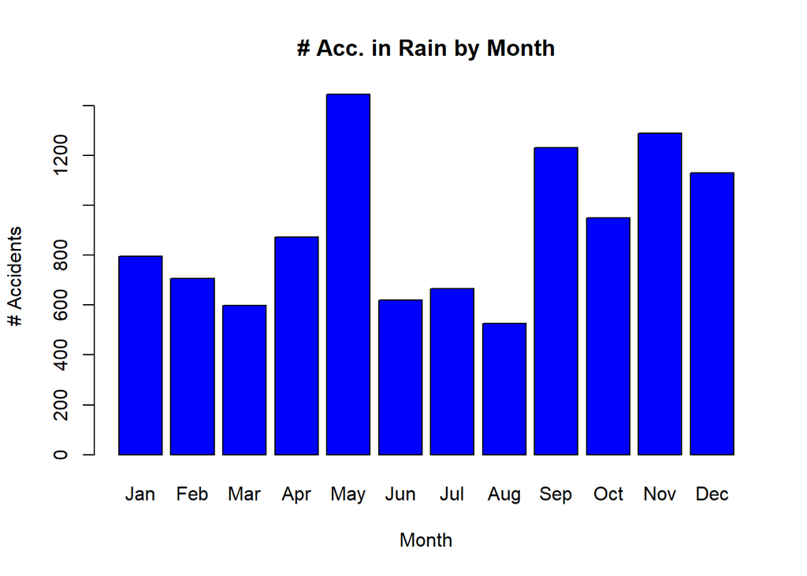

```r
dat$dtime = strptime(as.character(dat$Crash.Date.Time),
                     "%m/%d/%Y %I:%M:%S %p",
                     tz="America/New_York")
mnames=c("Jan","Feb","Mar","Apr","May","Jun","Jul","Aug","Sep","Oct","Nov","Dec")
wet_time = table(dat$Weather,dat$dtime$mon, exclude=c("OTHER","UNKNOWN","N/A"))
#raining crashes per month
barplot(wet_time[6,],main="# Acc. in Rain by Month",ylab="# Accidents",xlab="Month",names.arg = mnames,col="blue")
```

### **Accidents in January by Time**

May did have more rain than the rest of the months, but May did not have the most crashes by month so we cannot say that Rain significantly increases crashes per month.

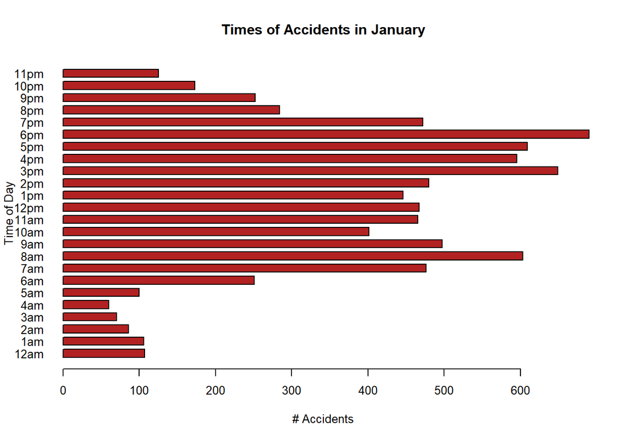

```r
par(cex=.8)
dat$dtime = strptime(as.character(dat$Crash.Date.Time),
                     "%m/%d/%Y %I:%M:%S %p",
                     tz="America/New_York")
# hours                   day                   month
tbl2 = table(substr(dat$dtime,12,13),substr(dat$dtime,6,7))
barplot(tbl2[,1],main="Times of Accidents in January",names.arg = c("12am","1am","2am","3am","4am","5am",
                               "6am","7am","8am","9am","10am","11am",
                               "12pm","1pm","2pm","3pm","4pm","5pm",
                               "6pm","7pm","8pm","9pm","10pm","11pm"),ylab="Time of Day",xlab="# Accidents", horiz = TRUE,las=1,space=c(.5),col="firebrick")
```

### **Accidents Involving Drugs/Alcohol by Month**

We took a closer look at January since it had most of the crashes. We thought most of these crashes would appear on January 1st because of the holiday. We expected to see most crashes to happen early morning on January but only noticed “normal” spikes in rush hour times.

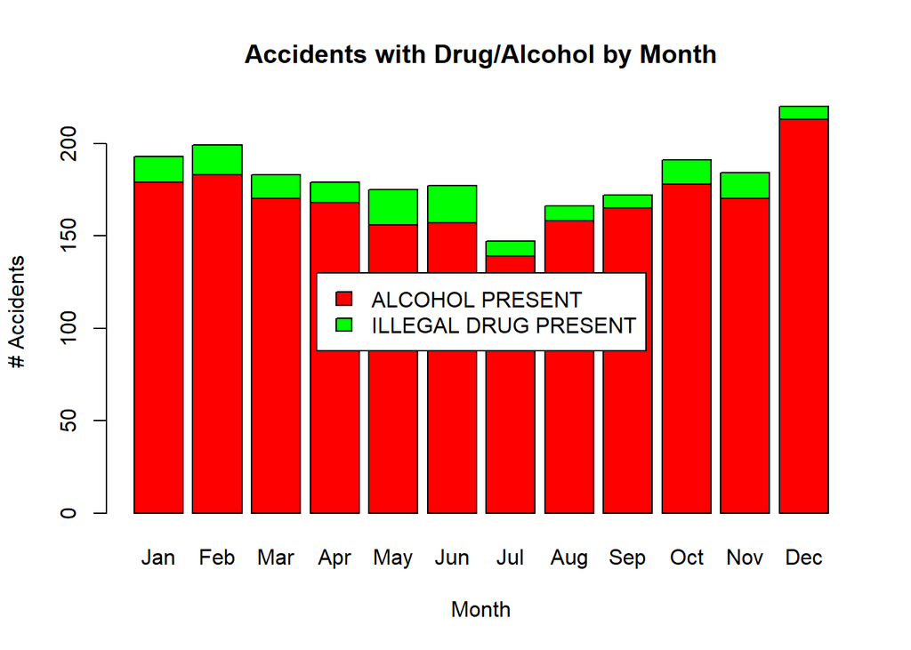

```r
drugs = dat$Driver.Substance.Abuse[dat$Driver.Substance.Abuse=="ALCOHOL CONTRIBUTED" | dat$Driver.Substance.Abuse=="ALCOHOL PRESENT" | dat$Driver.Substance.Abuse=="ILLEGAL DRUG CONTRIBUTED" | dat$Driver.Substance.Abuse=="ILLEGAL DRUG PRESENT"]
bd=table(dat$Driver.Substance.Abuse,substr(dat$dtime,6,7))
mnames=c("Jan","Feb","Mar","Apr","May","Jun","Jul","Aug","Sep","Oct","Nov","Dec")
barplot(bd[c(2, 6), ],main="Accidents with Drug/Alcohol by Month",names.arg=mnames,ylab="# Accidents",xlab="Month",col=c("red","green"))
legend("center",
       fill = c("red","green"),
       legend=rownames(bd[c(2, 6), ]))
```

### **Accidents Involving Alcohol by Month**

Next we looked deeper to see which months had notable numbers of alcohol related crashes

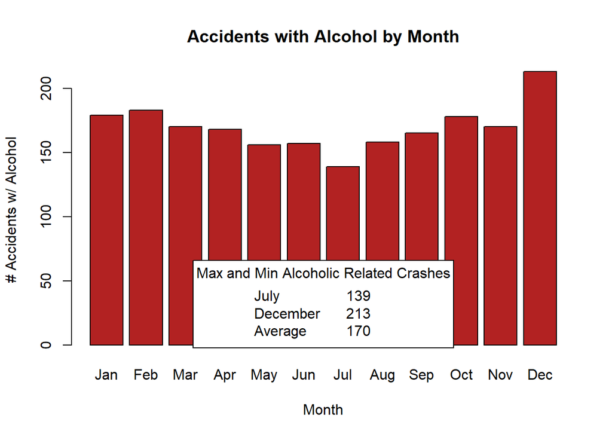

```r
mnames=c("Jan","Feb","Mar","Apr","May","Jun","Jul","Aug","Sep","Oct","Nov","Dec")
drug_mon=table(dat$Driver.Substance.Abuse,substr(dat$dtime,6,7))
a = drug_mon["ALCOHOL PRESENT",7]
b = drug_mon["ALCOHOL PRESENT",12]
c = mean(drug_mon["ALCOHOL PRESENT",])
hard_table = matrix(c(a,b,c),ncol=3,byrow = TRUE)
colnames(hard_table) = c("July","December","Average")
rownames(hard_table) = c("Crashes w/ Alcohol Present")
hard_table = as.table(hard_table)

barplot(drug_mon["ALCOHOL PRESENT",],main="Accidents with Alcohol by Month", names.arg = mnames,xlab="Month",ylab="# Accidents w/ Alcohol",col="firebrick")
legend("bottom",
       title = "Max and Min Alcoholic Related Crashes",
       legend = c(colnames(hard_table),round(hard_table[,1:3])),
        ncol=2
       )
```

The above graph shows alcoholic related crashes. We noticed a reverse bell curve with summer/spring crashes decreasing and winter/fall months increasing with alcohol related crashes.